# practical_exercise_5, Methods 3, 2021, autumn semester

Linus Backström

27.10.2021

# Exercises and objectives

The objectives of the exercises of this assignment are based on: https://doi.org/10.1016/j.concog.2019.03.007

4. Download and organise the data from experiment 1
5. Use log-likelihood ratio tests to evaluate logistic regression models
6. Test linear hypotheses
7. Estimate psychometric functions for the Perceptual Awareness Scale and evaluate them

REMEMBER: In your report, make sure to include code that can reproduce the answers requested in the exercises below (**MAKE A KNITTED VERSION**)  
REMEMBER: This is part 2 of Assignment 2 and will be part of your final portfolio

# EXERCISE 4 - Download and organise the data from experiment 1

Go to https://osf.io/ecxsj/files/ and download the files associated with Experiment 1 (there should be 29).  
The data is associated with Experiment 1 of the article at the following DOI https://doi.org/10.1016/j.concog.2019.03.007

1. Put the data from all subjects into a single data frame - note that some of the subjects do not have the *seed* variable. For these subjects, add this variable and make in *NA* for all observations. (The *seed* variable will not be part of the analysis and is not an experimental variable)

```r
df <-
    list.files(pattern = "*.csv") %>%
    map_df(~read_csv(.))
```

```
i. Factorise the variables that need factorising
```

```r
df$trial <- as.numeric(df$trial)
df$trial.type <- as.factor(df$trial.type)
df$pas <- as.factor(df$pas)
df$target.contrast <- as.numeric(df$target.contrast)
df$cue <- as.factor(df$cue)
df$task <- as.factor(df$task)
df$target.type <- as.factor(df$target.type)
df$rt.subj <- as.numeric(df$rt.subj)
df$rt.obj <- as.numeric(df$rt.obj)
df$obj.resp <- as.factor(df$obj.resp)
#Anonymize subjects (also facilitates later analysis if the subjects are represented only by numbers)
df$subject <- as.numeric(df$subject)
df$subject <- as.factor(df$subject)
```

```
ii. Remove the practice trials from the dataset (see the _trial.type_ variable)
```

```r
df <- df %>% filter(trial.type == 'experiment')
```

```
iii. Create a _correct_ variable
```

```r
df$correct <- as.factor(ifelse(df$obj.resp == 'e' & df$target.type == 'even' | df$obj.resp == 'o' & df$target.type == 'odd', 1, 0))
```

```
iv. Describe how the _target.contrast_ and _target.frames_ variables differ compared to the data from part 1 of this assignment
```

```r
unique(df$target.contrast)
```

```
## [1] 0.1
```

```r
unique(df$target.frames)
```

```
## [1] 3 2 1 5 6 4
```

The target contrast is always at 0.1.

# EXERCISE 5 - Use log-likelihood ratio tests to evaluate logistic regression models

1. Do logistic regression - *correct* as the dependent variable and *target.frames* as the independent variable. (Make sure that you understand what *target.frames* encode). Create two models - a pooled model and a partial-pooling model. The partial-pooling model should include a subject-specific intercept.

```r
cp_m <- glm(correct ~ target.frames, data = df, family = binomial) # complete pooling
pp_m <- glmer(correct ~ target.frames + (1 | subject), data = df, family = binomial) # partial-pooling
```

```
i. the likelihood-function for logistic regression is: $L(p)={\displaystyle\prod_{i=1}^Np^{y_i}(1-p)^{(1-y_i)}}$ (Remember the probability mass function for the Bernoulli Distribution). Create a function that calculates the likelihood.
```

```r
# likelihood-function for logistic regression = Binomial Probability

df$correct_numeric <- as.numeric(df$correct)-1

lik_fun <- function(y, y_hat) {
  vector <- 0
  for (i in 1:length(y)) {
    vector[i]<- ((y_hat[i])**(y[i])) * (1-(y_hat[i]))**(1-(y[i]))
  }
  prod(vector)
}

lik_fun(df$correct_numeric, boot::inv.logit(fitted.values(cp_m)))
```

```
## [1] 0
```

```
ii. the log-likelihood-function for logistic regression is: $l(p) = {\displaystyle\sum_{i=1}^N}[y_i\ln{p}+(1-y_i)\ln{(1-p)}$. Create a function that calculates the log-likelihood
```

```r
loglik_fun <- function(y, y_hat) {
  y*log(y_hat)+(1-y)*log(1-y_hat)
}
```

[output not shown]

```r
sum(loglik_fun(df$correct_numeric, cp_m$fitted.values))
```

```
## [1] -10865.25
```

```r
logLik(cp_m)
```

```
## 'log Lik.' -10865.25 (df=2)
```

```r
# these values match

lik_fun(df$correct_numeric, cp_m$fitted.values)
```

```
## [1] 0
```

```r
# returns zero
```

The likelihood-function squares values that are close to zero, which quickly results in values that are rounded to zero on computers with limited precision.

```
iv. now show that the log-likelihood is a little off when applied to the partial pooling model - (the likelihood function is different for the multilevel function - see section 2.1 of https://www.researchgate.net/profile/Douglas-Bates/publication/2753537_Computational_Methods_for_Multilevel_Modelling/links/00b4953b4108d73427000000/Computational-Methods-for-Multilevel-Modelling.pdf if you are interested)
```

```r
sum(loglik_fun(df$correct_numeric, fitted.values(pp_m)))
```

```
## [1] -10565.53
```

```r
logLik(pp_m)
```

```
## 'log Lik.' -10622.03 (df=3)
```

2. Use log-likelihood ratio tests to argue for the addition of predictor variables, start from the null model, `glm(correct ~ 1, 'binomial', data)`, then add subject-level intercepts, then add a group-level effect of *target.frames* and finally add subject-level slopes for *target.frames*. Also assess whether or not a correlation between the subject-level slopes and the subject-level intercepts should be included.

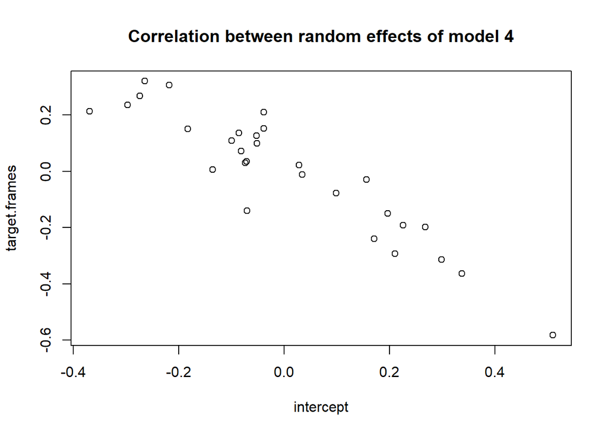

```r
m1 <- glm(correct~1, family='binomial', data=df)

m2 <- glmer(correct~1 + (1|subject), family='binomial', data=df)

m3 <- glmer(correct~1 + target.frames + (1|subject), family='binomial', data=df) # 'group level fx' = 'fixed fx'

m4 <- glmer(correct~1 + target.frames + (1+target.frames|subject), family='binomial', data=df)


lol <- ranef(m4)

for (i in seq(lol)){
  assign(paste0("lol", i), lol[[i]])
}

colnames(lol1) <- c("Intercept", "target.frames")

#We now plot the correlation between the random effects of intercept and slope.
plot(lol1$Intercept, lol1$target.frames, ylab="target.frames", xlab="intercept", main="Correlation between random effects of model 4")
```

```r
VarCorr(m4)
```

```
##  Groups  Name          Std.Dev. Corr
##  subject (Intercept)   0.24669
##          target.frames 0.22620  -0.870
```

From the plot we can observe that there is a negative correlation between the intercept and target.frames. We can also observe this from the VarCorr of model 4, finding a value of -0.87. Subjects that are above the global mean intercept, have less steep slopes. Essentially this means that subjects who have a higher baseline accuracy benefit less from additional frames than subjects with lower baseline accuracy.

```
i. write a short methods section and a results section where you indicate which model you chose and the statistics relevant for that choice. Include a plot of the estimated group-level function with `xlim=c(0, 8)` that includes the estimated subject-specific functions.
```

```r
anova(m4, m3, m2, m1)
```

|  | npar | AIC | BIC | logLik | deviance | Chisq | Df | Pr(>Chisq) |
| --- | --- | --- | --- | --- | --- | --- | --- | --- |
| m1 | 1 | 26685.08 | 26693.21 | -13341.54 | 26683.08 | NA | NA | NA |
| m2 | 2 | 26319.10 | 26335.35 | -13157.55 | 26315.10 | 367.9798 | 1 | 5.153061e-82 |
| m3 | 3 | 21250.06 | 21274.45 | -10622.03 | 21244.06 | 5071.0352 | 1 | 0.000000e+00 |
| m4 | 5 | 20907.65 | 20948.29 | -10448.83 | 20897.65 | 346.4127 | 2 | 5.990142e-76 |

```r
summary(m4)
```

```
## Generalized linear mixed model fit by maximum likelihood (Laplace
##   Approximation) [glmerMod]
##  Family: binomial  ( logit )
## Formula: correct ~ 1 + target.frames + (1 + target.frames | subject)
##    Data: df
##
##      AIC      BIC   logLik deviance df.resid
##  20907.7  20948.3 -10448.8  20897.7    25039
##
## Scaled residuals:
##      Min       1Q   Median       3Q      Max
## -16.1428   0.0812   0.2454   0.4868   1.2632
##
## Random effects:
##  Groups  Name          Variance Std.Dev. Corr
##  subject (Intercept)   0.06086  0.2467
##          target.frames 0.05117  0.2262   -0.87
## Number of obs: 25044, groups:  subject, 29
##
## Fixed effects:
##               Estimate Std. Error z value Pr(>|z|)
## (Intercept)   -1.09009    0.05876  -18.55   <2e-16 ***
## target.frames  0.83316    0.04432   18.80   <2e-16 ***
## ---
## Signif. codes:  0 '***' 0.001 '**' 0.01 '*' 0.05 '.' 0.1 ' ' 1
##
## Correlation of Fixed Effects:
##             (Intr)
## target.frms -0.817
```

The increasingly complex models are significantly better than their less complex counterparts, and model 4 (‘m4’) is the best one, as it also has the lowest AIC and BIC score. Model 4 is significantly different from model 3 (χ²(2)=346.41, p<0.001).

[figure not shown]

[output not shown]

```r
#changed boot::inv.logit(fitted(m4)) to just fitted(m4), seems to make more sense

df2 <- cbind(df, fitted = fitted(m4), probabilities = (fitted(m4)))
ggplot(df2, aes(x = target.frames, y = probabilities, color = subject)) +
  geom_line() +
  xlim(0, 8) +
  labs(x = "Number of target frames",
       y = "Probability of correct answer",
       title = "Estimated function by subject") +
  scale_color_discrete(name = "Subject")
```

The plot shows that the fit of subject 24 is off and the subject has lower accuracy than the rest.

```r
# We are unsure whether to test if their real performance or modeled performance is better than chance.

df_test <- data.frame(df, fitted(m4))
df_24 <- df_test %>% filter(subject == '24')
t.test(df_24$fitted.m4., mu=0.5)
```

```
##
##  One Sample t-test
##
## data:  df_24$fitted.m4.
## t = 20.451, df = 873, p-value < 2.2e-16
## alternative hypothesis: true mean is not equal to 0.5
## 95 percent confidence interval:
##  0.5640188 0.5776108
## sample estimates:
## mean of x
## 0.5708148
```

3. Now add *pas* to the group-level effects - if a log-likelihood ratio test justifies this, also add the interaction between *pas* and *target.frames* and check whether a log-likelihood ratio test justifies this

```r
library(dfoptim)
m5 <- glmer(correct~1 + target.frames + target.frames + pas + (1+target.frames|subject), family='binomial', data=df)
summary(m5)
```

```
## Generalized linear mixed model fit by maximum likelihood (Laplace
##   Approximation) [glmerMod]
##  Family: binomial  ( logit )
## Formula:
## correct ~ 1 + target.frames + target.frames + pas + (1 + target.frames |
##     subject)
##    Data: df
##
##      AIC      BIC   logLik deviance df.resid
##  19879.7  19944.7  -9931.8  19863.7    25036
##
## Scaled residuals:
##      Min       1Q   Median       3Q      Max
## -12.1836   0.0860   0.1931   0.4670   1.5004
##
## Random effects:
##  Groups  Name          Variance Std.Dev. Corr
##  subject (Intercept)   0.06447  0.2539
##          target.frames 0.02013  0.1419   -0.58
## Number of obs: 25044, groups:  subject, 29
##
## Fixed effects:
##               Estimate Std. Error z value Pr(>|z|)
## (Intercept)   -0.80032    0.06145 -13.024   <2e-16 ***
## target.frames  0.46935    0.03177  14.775   <2e-16 ***
## pas2           0.37038    0.04437   8.347   <2e-16 ***
## pas3           1.43410    0.06347  22.595   <2e-16 ***
## pas4           2.48918    0.10049  24.770   <2e-16 ***
## ---
## Signif. codes:  0 '***' 0.001 '**' 0.01 '*' 0.05 '.' 0.1 ' ' 1
##
## Correlation of Fixed Effects:
##             (Intr) trgt.f pas2   pas3
## target.frms -0.639
## pas2        -0.123 -0.146
## pas3         0.043 -0.252  0.400
## pas4         0.124 -0.268  0.258  0.294
```

```r
m6 <- glmer(correct~1 + target.frames + pas*target.frames + (1+target.frames|subject), family='binomial', data=df, control=glmerControl(optimizer='bobyqa'))
summary(m6)
```

```
## Generalized linear mixed model fit by maximum likelihood (Laplace
##   Approximation) [glmerMod]
##  Family: binomial  ( logit )
## Formula:
## correct ~ 1 + target.frames + pas * target.frames + (1 + target.frames |
##     subject)
##    Data: df
## Control: glmerControl(optimizer = "bobyqa")
##
##      AIC      BIC   logLik deviance df.resid
##  19506.1  19595.5  -9742.0  19484.1    25033
##
## Scaled residuals:
##      Min       1Q   Median       3Q      Max
## -19.0108   0.0537   0.1606   0.4849   1.4465
##
## Random effects:
##  Groups  Name          Variance Std.Dev. Corr
##  subject (Intercept)   0.03698  0.1923
##          target.frames 0.02058  0.1434   -0.76
## Number of obs: 25044, groups:  subject, 29
##
## Fixed effects:
##                    Estimate Std. Error z value Pr(>|z|)
## (Intercept)        -0.12163    0.06411  -1.897 0.057801 .
## target.frames       0.11480    0.03707   3.097 0.001955 **
## pas2               -0.57139    0.08937  -6.394 1.62e-10 ***
## pas3               -0.53850    0.13935  -3.864 0.000111 ***
## pas4                0.20159    0.24978   0.807 0.419619
## target.frames:pas2  0.44718    0.03473  12.878  < 2e-16 ***
## target.frames:pas3  0.74869    0.04589  16.314  < 2e-16 ***
## target.frames:pas4  0.75927    0.06830  11.116  < 2e-16 ***
## ---
## Signif. codes:  0 '***' 0.001 '**' 0.01 '*' 0.05 '.' 0.1 ' ' 1
##
## Correlation of Fixed Effects:
##             (Intr) trgt.f pas2   pas3   pas4   trg.:2 trg.:3
## target.frms -0.811
## pas2        -0.461  0.305
## pas3        -0.307  0.207  0.248
## pas4        -0.173  0.123  0.121  0.091
## trgt.frms:2  0.481 -0.428 -0.874 -0.244 -0.124
## trgt.frms:3  0.392 -0.358 -0.278 -0.891 -0.111  0.370
## trgt.frms:4  0.275 -0.260 -0.163 -0.120 -0.918  0.225  0.200
```

```r
anova(m6, m5, m4)
```

|  | npar | AIC | BIC | logLik | deviance | Chisq | Df | Pr(>Chisq) |
| --- | --- | --- | --- | --- | --- | --- | --- | --- |
| m4 | 5 | 20907.65 | 20948.29 | -10448.825 | 20897.65 | NA | NA | NA |
| m5 | 8 | 19879.66 | 19944.68 | -9931.828 | 19863.66 | 1033.9934 | 3 | 7.599679e-224 |
| m6 | 11 | 19506.08 | 19595.49 | -9742.039 | 19484.08 | 379.5781 | 3 | 5.866734e-82 |

[output not shown]

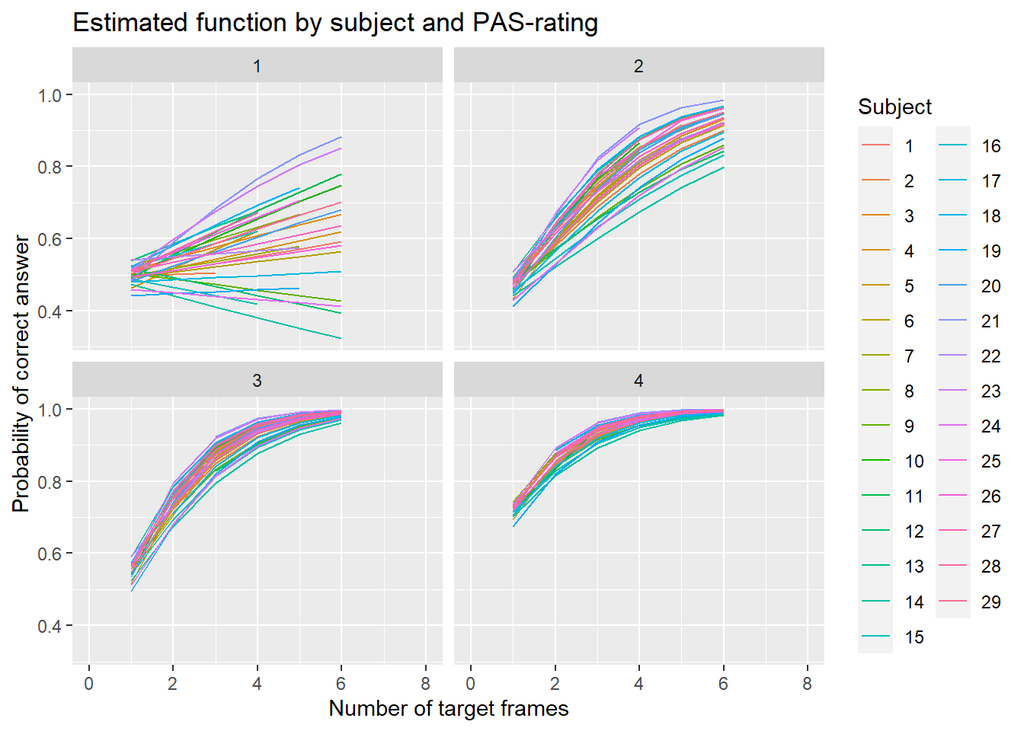

```r
df_m6 <- data.frame(df, fitted(m6))

five_3_ii <- ggplot(df_m6, aes(x = target.frames, y = fitted.m6., color = subject)) +
  geom_line() +
  xlim(0, 8) +
  facet_wrap(~pas)+
  labs(x = "Number of target frames",
       y = "Probability of correct answer",
       title = "Estimated function by subject and PAS-rating") +
  scale_color_discrete(name = "Subject")

five_3_ii
```

At target.frame=0 and PAS=1, the probability of a correct answer is 47%. This is close enough to chance (i.e. 50%) that we can conclude it is reasonable, because if no frames are shown, the participant can only guess. The achieved value of 47% is a lucky coincidence though, resulting from the fact that the slope for PAS-1 is nearly horizontal.

At target.frame=0 and PAS-ratings above 1 the model clearly falls apart (PAS-2 = 33%, PAS-3 = 34%, PAS-4 = 52%), because it doesn’t account for the fact that the lowest possible probability of a correct answer should be 50% in this sort of forced-choice experiment with two options.

# EXERCISE 6 - Test linear hypotheses

In this section we are going to test different hypotheses. We assume that we have already proved that more objective evidence (longer duration of stimuli) is sufficient to increase accuracy in and of itself and that more subjective evidence (higher PAS ratings) is also sufficient to increase accuracy in and of itself.  
We want to test a hypothesis for each of the three neighbouring differences in PAS, i.e. the difference between 2 and 1, the difference between 3 and 2 and the difference between 4 and 3. More specifically, we want to test the hypothesis that accuracy increases faster with objective evidence if subjective evidence is higher at the same time, i.e. we want to test for an interaction.

1. Fit a model based on the following formula: `correct ~ pas * target.frames + (target.frames | subject))`
   1. First, use `summary` (yes, you are allowed to!) to argue that accuracy increases faster with objective evidence for PAS-2 than for PAS-1.

```r
m7 <- glmer(correct ~ pas * target.frames + (target.frames|subject), family='binomial', data=df)
summary(m7)
```

```
## Generalized linear mixed model fit by maximum likelihood (Laplace
##   Approximation) [glmerMod]
##  Family: binomial  ( logit )
## Formula: correct ~ pas * target.frames + (target.frames | subject)
##    Data: df
##
##      AIC      BIC   logLik deviance df.resid
##  19506.1  19595.5  -9742.0  19484.1    25033
##
## Scaled residuals:
##      Min       1Q   Median       3Q      Max
## -19.0113   0.0537   0.1606   0.4849   1.4465
##
## Random effects:
##  Groups  Name          Variance Std.Dev. Corr
##  subject (Intercept)   0.03697  0.1923
##          target.frames 0.02057  0.1434   -0.76
## Number of obs: 25044, groups:  subject, 29
##
## Fixed effects:
##                    Estimate Std. Error z value Pr(>|z|)
## (Intercept)        -0.12163    0.06415  -1.896 0.057980 .
## pas2               -0.57139    0.08942  -6.390 1.66e-10 ***
## pas3               -0.53850    0.13955  -3.859 0.000114 ***
## pas4                0.20153    0.25024   0.805 0.420626
## target.frames       0.11480    0.03709   3.095 0.001965 **
## pas2:target.frames  0.44718    0.03474  12.871  < 2e-16 ***
## pas3:target.frames  0.74869    0.04595  16.294  < 2e-16 ***
## pas4:target.frames  0.75929    0.06842  11.098  < 2e-16 ***
## ---
## Signif. codes:  0 '***' 0.001 '**' 0.01 '*' 0.05 '.' 0.1 ' ' 1
##
## Correlation of Fixed Effects:
##             (Intr) pas2   pas3   pas4   trgt.f ps2:t. ps3:t.
## pas2        -0.462
## pas3        -0.308  0.248
## pas4        -0.174  0.121  0.090
## target.frms -0.811  0.306  0.208  0.123
## ps2:trgt.fr  0.482 -0.874 -0.245 -0.124 -0.428
## ps3:trgt.fr  0.393 -0.279 -0.891 -0.111 -0.358  0.370
## ps4:trgt.fr  0.276 -0.163 -0.120 -0.918 -0.260  0.225  0.199
```

We can observe that pas2:target.frames is 0.44718 (p<.05), which is a positive value, confirming that accuracy increases faster with each additional frame for PAS-2 vs PAS-1.

2. `summary` won’t allow you to test whether accuracy increases faster with objective evidence for PAS 3 than for PAS 2 (unless you use `relevel`, which you are not allowed to in this exercise). Instead, we’ll be using the function `glht` from the `multcomp` package
   1. To redo the test in 6.1.i, you can create a *contrast* vector. This vector will have the length of the number of estimated group-level effects and any specific contrast you can think of can be specified using this. For redoing the test from 6.1.i, the code snippet below will do

```r
library(multcomp)
## testing whether PAS 2 is different from PAS 1
contrast.vector <- matrix(c(0, 0, 0, 0, 0, 1, 0, 0), nrow=1)
gh <- glht(m7, contrast.vector)
print(summary(gh))
```

```
##
##   Simultaneous Tests for General Linear Hypotheses
##
## Fit: glmer(formula = correct ~ pas * target.frames + (target.frames |
##     subject), data = df, family = "binomial")
##
## Linear Hypotheses:
##        Estimate Std. Error z value Pr(>|z|)
## 1 == 0  0.44718    0.03474   12.87   <2e-16 ***
## ---
## Signif. codes:  0 '***' 0.001 '**' 0.01 '*' 0.05 '.' 0.1 ' ' 1
## (Adjusted p values reported -- single-step method)
```

```r
## as another example, we could also test whether there is a difference in
## intercepts between PAS 2 and PAS 3
contrast.vector <- matrix(c(0, -1, 1, 0, 0, 0, 0, 0), nrow=1)
gh2 <- glht(m7, contrast.vector)
print(summary(gh2))
```

```
##
##   Simultaneous Tests for General Linear Hypotheses
##
## Fit: glmer(formula = correct ~ pas * target.frames + (target.frames |
##     subject), data = df, family = "binomial")
##
## Linear Hypotheses:
##        Estimate Std. Error z value Pr(>|z|)
## 1 == 0  0.03289    0.14588   0.225    0.822
## (Adjusted p values reported -- single-step method)
```

```
ii. Now test the hypothesis that accuracy increases faster with objective evidence for PAS 3 than for PAS 2.
```

```r
## testing whether PAS 3 is different from PAS 2
contrast.vector <- matrix(c(0, 0, 0, 0, 0, -1, 1, 0), nrow=1) #the zeros stand for the rows in the fixed effects summary
gh <- glht(m7, contrast.vector)
print(summary(gh))
```

```
##
##   Simultaneous Tests for General Linear Hypotheses
##
## Fit: glmer(formula = correct ~ pas * target.frames + (target.frames |
##     subject), data = df, family = "binomial")
##
## Linear Hypotheses:
##        Estimate Std. Error z value Pr(>|z|)
## 1 == 0  0.30151    0.04622   6.524 6.85e-11 ***
## ---
## Signif. codes:  0 '***' 0.001 '**' 0.01 '*' 0.05 '.' 0.1 ' ' 1
## (Adjusted p values reported -- single-step method)
```

0.30151, p<.001

```
iii. Also test the hypothesis that accuracy increases faster with objective evidence for PAS 4 than for PAS 3
```

```r
## testing whether PAS 4 is different from PAS 3
contrast.vector <- matrix(c(0, 0, 0, 0, 0, 0, -1, 1), nrow=1) #the zeros stand for the rows in the fixed effects summary
gh <- glht(m7, contrast.vector)
print(summary(gh))
```

```
##
##   Simultaneous Tests for General Linear Hypotheses
##
## Fit: glmer(formula = correct ~ pas * target.frames + (target.frames |
##     subject), data = df, family = "binomial")
##
## Linear Hypotheses:
##        Estimate Std. Error z value Pr(>|z|)
## 1 == 0  0.01060    0.07442   0.142    0.887
## (Adjusted p values reported -- single-step method)
```

0.0106, p>.05

3. Finally, test that whether the difference between PAS 2 and 1 (tested in 6.1.i) is greater than the difference between PAS 4 and 3 (tested in 6.2.iii)

We can observe that the difference between PAS-2 and 1 (0.44718) is larger than that of PAS-4 and 3 (0.0106).

# EXERCISE 7 - Estimate psychometric functions for the Perceptual Awareness Scale and evaluate them

We saw in 5.3 that the estimated functions went below chance at a target duration of 0 frames (0 ms). This does not seem reasonable, so we will be trying a different approach for fitting here.  
We will fit the following function that results in a sigmoid, $f(x) = a + \frac {b - a} {1 + e^{\frac {c-x} {d}}}$  
It has four parameters: *a*, which can be interpreted as the minimum accuracy level, *b*, which can be interpreted as the maximum accuracy level, *c*, which can be interpreted as the so-called inflexion point, i.e. where the derivative of the sigmoid reaches its maximum and *d*, which can be interpreted as the steepness at the inflexion point. (When *d* goes towards infinity, the slope goes towards a straight line, and when it goes towards 0, the slope goes towards a step function).

We can define a function of a residual sum of squares as below

```r
RSS_func <- function(dataset, par)
{
    ## "dataset" should be a data.frame containing the variables x (target.frames)
    ## and y (correct)

    ## "par" are our four parameters (a numeric vector)
    ## par[1]=a, par[2]=b, par[3]=c, par[4]=d
    x <- dataset$x
    y <- dataset$y
    y.hat <- par[1] + (par[2]-par[1]) / (1+exp(par[3]-x)/par[4]) ## sigmoid function
    RSS <- sum((y - y.hat)^2)
    return(RSS)
}
```

1. Now, we will fit the sigmoid for the four PAS ratings for Subject 7

```r
subject7 <- df %>% filter(subject == '7')
subject7$x <- subject7$target.frames
subject7$y <- subject7$correct_numeric
```

```
i. use the function `optim`. It returns a list that among other things contains the four estimated parameters. You should set the following arguments:
`par`: you can set _c_ and _d_ as 1. Find good choices for _a_ and _b_ yourself (and argue why they are appropriate)
`fn`: which function to minimise?
`data`: the data frame with _x_, _target.frames_, and _y_, _correct_ in it
`method`: 'L-BFGS-B'
`lower`: lower bounds for the four parameters, (the lowest value they can take), you can set _c_ and _d_ as `-Inf`. Find good choices for _a_ and _b_ yourself (and argue why they are appropriate)
`upper`: upper bounds for the four parameters, (the highest value they can take) can set _c_ and _d_ as `Inf`. Find good choices for _a_ and _b_ yourself (and argue why they are appropriate)
```

```r
optim(par = c(0.5, 1, 1, 1),
      fn = RSS_func,
      data = subject7,
      method = 'L-BFGS-B',
      lower = c(0.5, 0.5, -Inf, -Inf),
      upper = c(1, 1, Inf, Inf)
      )
```

```
## $par
## [1] 0.5000000 1.0000000 1.6516003 0.3523453
##
## $value
## [1] 104.9364
##
## $counts
## function gradient
##        8        8
##
## $convergence
## [1] 0
##
## $message
## [1] "CONVERGENCE: REL_REDUCTION_OF_F <= FACTR*EPSMCH"
```

```r
#Creating separate dataframes for each PAS-rating

df1 <- data.frame(subject = df$subject, x = df$target.frames, y = df$correct_numeric, pas = df$pas)

df_p1 <- df1 %>% filter(pas == '1')
df_p2 <- df1 %>% filter(pas == '2')
df_p3 <- df1 %>% filter(pas == '3')
df_p4 <- df1 %>% filter(pas == '4')

p1_o <- optim(par = c(0.5, 1, 1, 1),
      fn = RSS_func,
      data = df_p1,
      method = 'L-BFGS-B',
      lower = c(0.5, 0.5, -Inf, -Inf),
      upper = c(1, 1, Inf, Inf)
      )

p2_o <- optim(par = c(0.5, 1, 1, 1),
      fn = RSS_func,
      data = df_p2,
      method = 'L-BFGS-B',
      lower = c(0.5, 0.5, -Inf, -Inf),
      upper = c(1, 1, Inf, Inf)
      )

p3_o <- optim(par = c(0.5, 1, 1, 1),
      fn = RSS_func,
      data = df_p3,
      method = 'L-BFGS-B',
      lower = c(0.5, 0.5, -Inf, -Inf),
      upper = c(1, 1, Inf, Inf)
      )

p4_o <- optim(par = c(0.5, 1, 1, 1),
      fn = RSS_func,
      data = df_p4,
      method = 'L-BFGS-B',
      lower = c(0.5, 0.5, -Inf, -Inf),
      upper = c(1, 1, Inf, Inf)
      )

sigmoid_y_hat <- function(dataset, par)
{
    ## "dataset" should be a data.frame containing the variables x (target.frames)
    ## and y (correct)

    ## "par" are our four parameters (a numeric vector)
    ## par[1]=a, par[2]=b, par[3]=c, par[4]=d
    x <- dataset$x
    y <- dataset$y
    y.hat <- par[1] + (par[2]-par[1]) / (1+exp(par[3]-x)/par[4]) ## sigmoid function
    return(y.hat)
}

df_p1$yhat <- sigmoid_y_hat(df_p1, p1_o$par)
df_p2$yhat <- sigmoid_y_hat(df_p2, p2_o$par)
df_p3$yhat <- sigmoid_y_hat(df_p3, p3_o$par)
df_p4$yhat <- sigmoid_y_hat(df_p4, p4_o$par)

subject7_p1 <- df_p1 %>% filter(subject == '7')
subject7_p2 <- df_p2 %>% filter(subject == '7')
subject7_p3 <- df_p3 %>% filter(subject == '7')
subject7_p4 <- df_p4 %>% filter(subject == '7')

subject7_p <- rbind(subject7_p1, subject7_p2, subject7_p3, subject7_p4)
```

```
ii. Plot the fits for the PAS ratings on a single plot (for subject 7) `xlim=c(0, 8)`
```

```r
s7_p1 <- ggplot(subject7_p, aes(x = x, y = yhat, color = pas)) +
  geom_line() +
  xlim(0, 8) +
  labs(x = "Number of target frames",
       y = "Probability of correct answer",
       title = "Subject 7") +
  scale_color_discrete(name = "PAS")
```

```
iii. Create a similar plot for the PAS ratings on a single plot (for subject 7), but this time based on the model from 6.1 `xlim=c(0, 8)`
```

[figure not shown]

```
iv. Comment on the differences between the fits - mention some advantages and disadvantages of each way
```

```r
df_subject7 <- df
df_subject7$fitted_m7 <- fitted.values(m7)
df_subject7 <- df_subject7 %>%
  filter(subject== '7')

s7_p2 <- ggplot(df_subject7, aes(x = target.frames, y = fitted_m7, color = pas)) +
  geom_line() +
  xlim(0, 8) +
  labs(x = "Number of target frames",
       y = "Probability of correct answer",
       title = "Subject7, model 7") +
  scale_color_discrete(name = "PAS")

library(gridExtra)
grid.arrange(s7_p1, s7_p2)
```

Model 7, unlike the other fit, does not take into account that 0.5 should be the lowest possible probability, and assigns values less than 0.5 to PAS-ratings 1 and 2 at one target frame.

2. Finally, estimate the parameters for all subjects and each of their four PAS ratings. Then plot the estimated function at the group-level by taking the mean for each of the four parameters, *a*, *b*, *c* and *d* across subjects. A function should be estimated for each PAS-rating (it should look somewhat similar to Fig. 3 from the article: https://doi.org/10.1016/j.concog.2019.03.007)

```r
n <- length(unique(df1$subject))

for (i in 1:n) {
  df_bla <- df1 %>%
  filter(subject == i) %>%
  dplyr::select(x, y, pas)

  pas1 <- optim(par = c(0.5,1,1,1), fn=RSS_func, data = filter(df_bla, pas == "1"), method = 'L-BFGS-B', lower = c(0.5,0.5,-Inf,-Inf), upper = c(1,1,Inf,Inf))
  pas2 <- optim(par = c(0.5,1,1,1), fn=RSS_func, data = filter(df_bla, pas == "2"), method = 'L-BFGS-B', lower = c(0.5,0.5,-Inf,-Inf), upper = c(1,1,Inf,Inf))
  pas3 <- optim(par = c(0.5,1,1,1), fn=RSS_func, data = filter(df_bla, pas == "3"), method = 'L-BFGS-B', lower = c(0.5,0.5,-Inf,-Inf), upper = c(1,1,Inf,Inf))
  pas4 <- optim(par = c(0.5,1,1,1), fn=RSS_func, data = filter(df_bla, pas == "4"), method = 'L-BFGS-B', lower = c(0.5,0.5,-Inf,-Inf), upper = c(1,1,Inf,Inf))

  df_bla$yhat_pas1_all <- pas1$par[1] + ((pas1$par[2]-pas1$par[1])/(1+exp(1)^((pas1$par[3]-df_bla$x)/pas1$par[4])))
  df_bla$yhat_pas2_all <- pas2$par[1] + ((pas2$par[2]-pas2$par[1])/(1+exp(1)^((pas2$par[3]-df_bla$x)/pas2$par[4])))
  df_bla$yhat_pas3_all <- pas3$par[1] + ((pas3$par[2]-pas3$par[1])/(1+exp(1)^((pas3$par[3]-df_bla$x)/pas3$par[4])))
  df_bla$yhat_pas4_all <- pas4$par[1] + ((pas4$par[2]-pas4$par[1])/(1+exp(1)^((pas4$par[3]-df_bla$x)/pas4$par[4])))


}

df_bla_x1 <- df_bla %>%
  filter(x == 1) %>%
  group_by(pas) %>%
  summarise(mean(yhat_pas1_all), mean(yhat_pas2_all), mean(yhat_pas3_all), mean(yhat_pas4_all))
df_bla_x1$x = 1

df_bla_x2 <- df_bla %>%
  filter(x == 2) %>%
  group_by(pas) %>%
  summarise(mean(yhat_pas1_all), mean(yhat_pas2_all), mean(yhat_pas3_all), mean(yhat_pas4_all))
df_bla_x2$x = 2

df_bla_x3 <- df_bla %>%
  filter(x == 3) %>%
  group_by(pas) %>%
  summarise(mean(yhat_pas1_all), mean(yhat_pas2_all), mean(yhat_pas3_all), mean(yhat_pas4_all))
df_bla_x3$x = 3

df_bla_x4 <- df_bla %>%
  filter(x == 4) %>%
  group_by(pas) %>%
  summarise(mean(yhat_pas1_all), mean(yhat_pas2_all), mean(yhat_pas3_all), mean(yhat_pas4_all))
df_bla_x4$x = 4

df_bla_x5 <- df_bla %>%
  filter(x == 5) %>%
  group_by(pas) %>%
  summarise(mean(yhat_pas1_all), mean(yhat_pas2_all), mean(yhat_pas3_all), mean(yhat_pas4_all))
df_bla_x5$x = 5

df_bla_x6 <- df_bla %>%
  filter(x == 6) %>%
  group_by(pas) %>%
  summarise(mean(yhat_pas1_all), mean(yhat_pas2_all), mean(yhat_pas3_all), mean(yhat_pas4_all))
df_bla_x6$x = 6

df_mean <- as.data.frame(rbind(df_bla_x1, df_bla_x2, df_bla_x3, df_bla_x4, df_bla_x5, df_bla_x6))

all_subjects_mean <- df_mean %>%
  ggplot() +
  geom_line(aes(x = x, y = `mean(yhat_pas1_all)`, color = "pas1")) +
  geom_line(aes(x = x, y = `mean(yhat_pas2_all)`, color = "pas2")) +
  geom_line(aes(x = x, y = `mean(yhat_pas3_all)`, color = "pas3")) +
  geom_line(aes(x = x, y = `mean(yhat_pas4_all)`, color = "pas4")) +
  labs(title = "All subjects",
       x = "Number of target frames",
       y = "Probability of correct answer") +
  theme_bw()
```

```
i. compare with the figure you made in 5.3.ii and comment on the differences between the fits - mention some advantages and disadvantages of both.
```

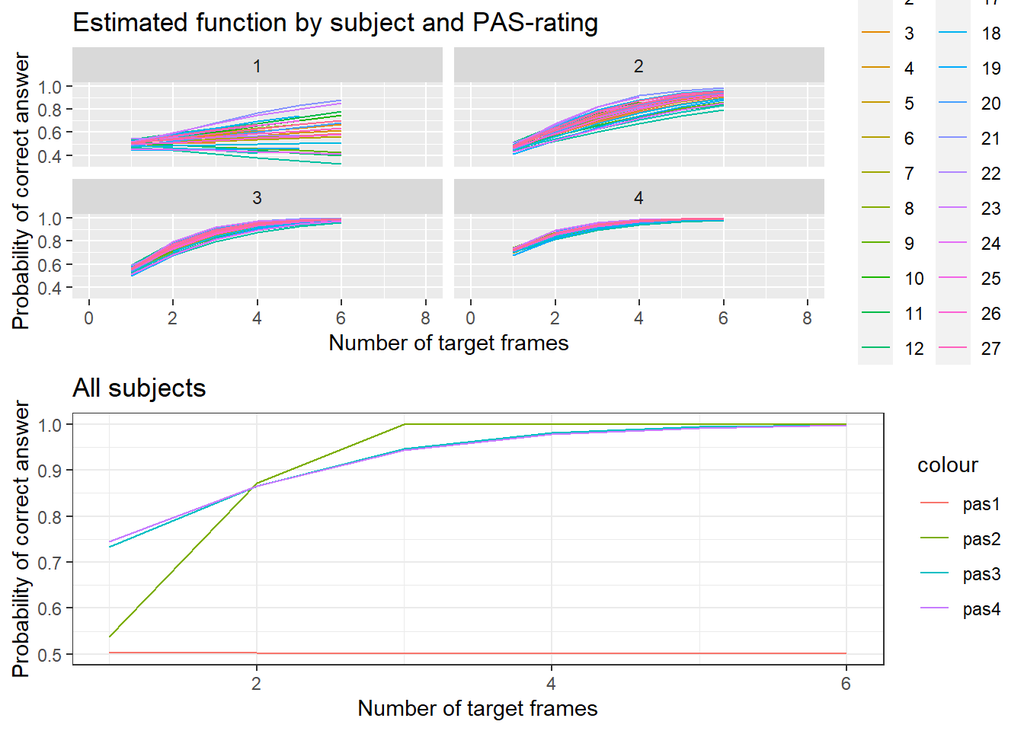

```r
grid.arrange(five_3_ii, all_subjects_mean)
```

The largest difference can be seen for the PAS-2 curve, which is much steeper from target frames 1-3 in the lower figure, and then reaching the max. value of 1. PAS-3 and PAS-4 are also at higher values in the lower figure.